# Praca Domowa I

Paulina Przybyłek

9 marca 2020

## Wprowadzenie

Zajmiemy się analizą zbioru Heart Disease, który można pobrać ze strony https://www.mldata.io/dataset-details/heart_disease/. Słowem wstępu, zbiór zawiera dane zebrane od 303 pacjentów ze szpitala z Cleveland i przedstawia je w postaci 14 artybutów dla każdego z nich (m.in. wiek, płeć, ciśnienie krwi, tętno).

Na początek spójrzmy jak wygląda zbiór po wczytaniu go:

Tab.1. Fragment ramki danych

| age | sex | cp | trestbps | chol | fbs | restecg | thalach | exang | oldpeak | slope | ca | thal | num |
| --- | --- | --- | --- | --- | --- | --- | --- | --- | --- | --- | --- | --- | --- |
| 63 | 1 | 1 | 145 | 233 | 1 | 2 | 150 | 0 | 2.3 | 3 | 0 | 6 | 0 |
| 67 | 1 | 4 | 160 | 286 | 0 | 2 | 108 | 1 | 1.5 | 2 | 3 | 3 | 1 |
| 67 | 1 | 4 | 120 | 229 | 0 | 2 | 129 | 1 | 2.6 | 2 | 2 | 7 | 1 |
| 37 | 1 | 3 | 130 | 250 | 0 | 0 | 187 | 0 | 3.5 | 3 | 0 | 3 | 0 |
| 41 | 0 | 2 | 130 | 204 | 0 | 2 | 172 | 0 | 1.4 | 1 | 0 | 3 | 0 |
| 56 | 1 | 2 | 120 | 236 | 0 | 0 | 178 | 0 | 0.8 | 1 | 0 | 3 | 0 |

Zanim przejdziemy do analizy tego zbioru warto wiedzieć dokładnie co zabiera jaka kolumna i jakich wartości mamy się spodziewać.

## Analiza Danych

### Statystyki

Wiemy już jaki mamy zbiór i jakie zawiera on dane, więc przyjrzyjmy się im teraz dokładniej. Zacznijmy od sprawdzenia typów danych.

```
## Classes 'data.table' and 'data.frame':   303 obs. of  14 variables:
##  $ age     : int  63 67 67 37 41 56 62 57 63 53 ...
##  $ sex     : int  1 1 1 1 0 1 0 0 1 1 ...
##  $ cp      : int  1 4 4 3 2 2 4 4 4 4 ...
##  $ trestbps: int  145 160 120 130 130 120 140 120 130 140 ...
##  $ chol    : int  233 286 229 250 204 236 268 354 254 203 ...
##  $ fbs     : int  1 0 0 0 0 0 0 0 0 1 ...
##  $ restecg : int  2 2 2 0 2 0 2 0 2 2 ...
##  $ thalach : int  150 108 129 187 172 178 160 163 147 155 ...
##  $ exang   : int  0 1 1 0 0 0 0 1 0 1 ...
##  $ oldpeak : num  2.3 1.5 2.6 3.5 1.4 0.8 3.6 0.6 1.4 3.1 ...
##  $ slope   : int  3 2 2 3 1 1 3 1 2 3 ...
##  $ ca      : int  0 3 2 0 0 0 2 0 1 0 ...
##  $ thal    : int  6 3 7 3 3 3 3 3 7 7 ...
##  $ num     : int  0 1 1 0 0 0 1 0 1 1 ...
##  - attr(*, ".internal.selfref")=<externalptr>
```

Mamy kilka danych kategorycznych i ciągłych, co może być ciekawe przy eksploracji. Teraz sprawdźmy statystyki podsumowujące dla naszych danych - musimy się przygotować na to, że jest to 14 kolumn i możliwe jest, iż nic nie zauważymy. Dodatkowo, nudne będą statystyki dla kolumn, które przyjmują tylko 0 albo 1, ale sprawdźmy to.

Tab.2. Statystyki danych

|  | age | sex | cp | trestbps | chol | fbs | restecg | thalach | exang | oldpeak | slope | ca | thal | num |
| --- | --- | --- | --- | --- | --- | --- | --- | --- | --- | --- | --- | --- | --- | --- |
|  | Min. :29.00 | Min. :0.0000 | Min. :1.000 | Min. : 94.0 | Min. :126.0 | Min. :0.0000 | Min. :0.0000 | Min. : 71.0 | Min. :0.0000 | Min. :0.00 | Min. :1.000 | Min. :-100000 | Min. :-100000.0 | Min. :0.0000 |
|  | 1st Qu.:48.00 | 1st Qu.:0.0000 | 1st Qu.:3.000 | 1st Qu.:120.0 | 1st Qu.:211.0 | 1st Qu.:0.0000 | 1st Qu.:0.0000 | 1st Qu.:133.5 | 1st Qu.:0.0000 | 1st Qu.:0.00 | 1st Qu.:1.000 | 1st Qu.: 0 | 1st Qu.: 3.0 | 1st Qu.:0.0000 |
|  | Median :56.00 | Median :1.0000 | Median :3.000 | Median :130.0 | Median :241.0 | Median :0.0000 | Median :1.0000 | Median :153.0 | Median :0.0000 | Median :0.80 | Median :2.000 | Median : 0 | Median : 3.0 | Median :0.0000 |
|  | Mean :54.44 | Mean :0.6799 | Mean :3.158 | Mean :131.7 | Mean :246.7 | Mean :0.1485 | Mean :0.9901 | Mean :149.6 | Mean :0.3267 | Mean :1.04 | Mean :1.601 | Mean : -1319 | Mean : -655.4 | Mean :0.4587 |
|  | 3rd Qu.:61.00 | 3rd Qu.:1.0000 | 3rd Qu.:4.000 | 3rd Qu.:140.0 | 3rd Qu.:275.0 | 3rd Qu.:0.0000 | 3rd Qu.:2.0000 | 3rd Qu.:166.0 | 3rd Qu.:1.0000 | 3rd Qu.:1.60 | 3rd Qu.:2.000 | 3rd Qu.: 1 | 3rd Qu.: 7.0 | 3rd Qu.:1.0000 |
|  | Max. :77.00 | Max. :1.0000 | Max. :4.000 | Max. :200.0 | Max. :564.0 | Max. :1.0000 | Max. :2.0000 | Max. :202.0 | Max. :1.0000 | Max. :6.20 | Max. :3.000 | Max. : 3 | Max. : 7.0 | Max. :1.0000 |

W **Tab.2.** mamy zawarte nasze statystyki, może nie od razu, ale rzuca się w oczy minimum równe -100 000 przy kolumnie ca i thal, a z poprzedniego punktu wiemy, że nie przyjmują one takich wartości. Co to może oznaczać? Prawdopodobnie braki danych w tych kolumnach, albowiem na stronie, z której możemy pobrać zbiór, wspomniane jest, że takie braki występują. Przywróćmy odpowiedni typ brakującym danym, czyli nadajmy im wartości NA.

```r
data$ca <- if_else(data$ca < 0, NA_integer_, data$ca)
data$thal <- if_else(data$thal < 0, NA_integer_, data$thal)
```

Tab.3. Statystyki danych przy uwzględnieniu braków danych

|  | age | sex | cp | trestbps | chol | fbs | restecg | thalach | exang | oldpeak | slope | ca | thal | num |
| --- | --- | --- | --- | --- | --- | --- | --- | --- | --- | --- | --- | --- | --- | --- |
|  | Min. :29.00 | Min. :0.0000 | Min. :1.000 | Min. : 94.0 | Min. :126.0 | Min. :0.0000 | Min. :0.0000 | Min. : 71.0 | Min. :0.0000 | Min. :0.00 | Min. :1.000 | Min. :0.0000 | Min. :3.000 | Min. :0.0000 |
|  | 1st Qu.:48.00 | 1st Qu.:0.0000 | 1st Qu.:3.000 | 1st Qu.:120.0 | 1st Qu.:211.0 | 1st Qu.:0.0000 | 1st Qu.:0.0000 | 1st Qu.:133.5 | 1st Qu.:0.0000 | 1st Qu.:0.00 | 1st Qu.:1.000 | 1st Qu.:0.0000 | 1st Qu.:3.000 | 1st Qu.:0.0000 |
|  | Median :56.00 | Median :1.0000 | Median :3.000 | Median :130.0 | Median :241.0 | Median :0.0000 | Median :1.0000 | Median :153.0 | Median :0.0000 | Median :0.80 | Median :2.000 | Median :0.0000 | Median :3.000 | Median :0.0000 |
|  | Mean :54.44 | Mean :0.6799 | Mean :3.158 | Mean :131.7 | Mean :246.7 | Mean :0.1485 | Mean :0.9901 | Mean :149.6 | Mean :0.3267 | Mean :1.04 | Mean :1.601 | Mean :0.6722 | Mean :4.734 | Mean :0.4587 |
|  | 3rd Qu.:61.00 | 3rd Qu.:1.0000 | 3rd Qu.:4.000 | 3rd Qu.:140.0 | 3rd Qu.:275.0 | 3rd Qu.:0.0000 | 3rd Qu.:2.0000 | 3rd Qu.:166.0 | 3rd Qu.:1.0000 | 3rd Qu.:1.60 | 3rd Qu.:2.000 | 3rd Qu.:1.0000 | 3rd Qu.:7.000 | 3rd Qu.:1.0000 |
|  | Max. :77.00 | Max. :1.0000 | Max. :4.000 | Max. :200.0 | Max. :564.0 | Max. :1.0000 | Max. :2.0000 | Max. :202.0 | Max. :1.0000 | Max. :6.20 | Max. :3.000 | Max. :3.0000 | Max. :7.000 | Max. :1.0000 |
|  | NA | NA | NA | NA | NA | NA | NA | NA | NA | NA | NA | NA’s :4 | NA’s :2 | NA |

Przy ponownym wywołaniu statystyk na zbiorze pojawiła się kolejna wartość - liczba NA w danej kolumnie. Jak widać liczba missing values, to jest brakujących wartości, jest niewielka (co widać też, na wykresie poniżej).

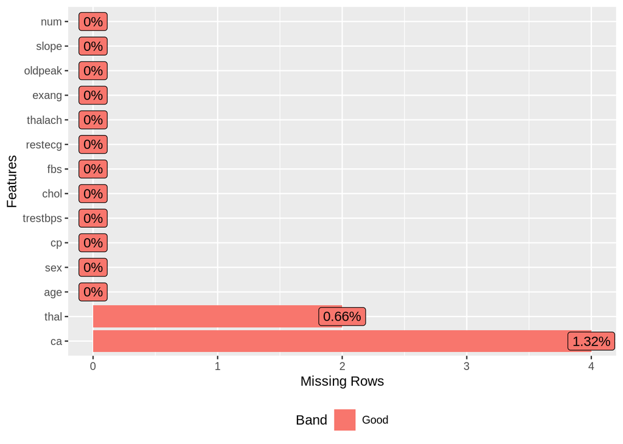

### Rozkłady zmiennych i korelacje między nimi

Wykorzystajmy pakiet DataExplorer w celu obejrzenia naszych zmeinnych ciągłych i kategorycznych. Pakiet sam wybrał jakie kolumny uznaje za zmienne ciągłe a jakie za dyskretne.

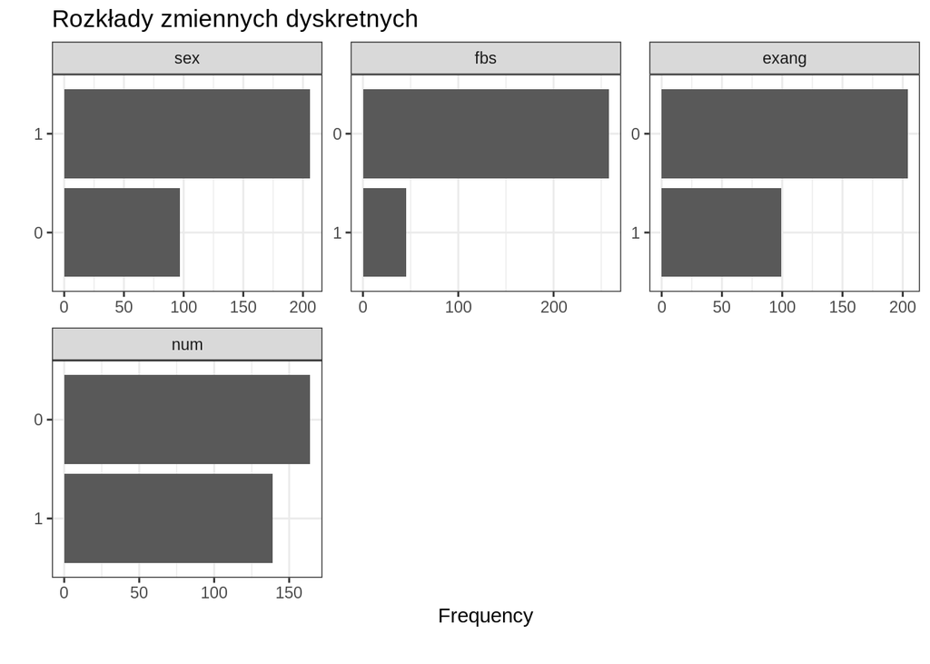

```r
plot_bar(data, ggtheme = theme_bw(), title = "Rozkłady zmiennych dyskretnych")
```

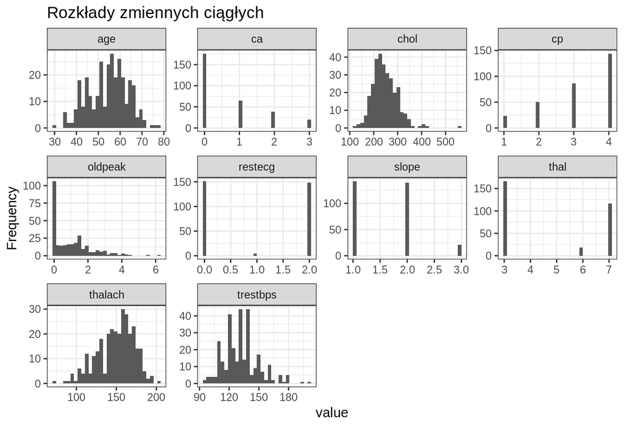

```r
plot_histogram(data, ggtheme = theme_bw(), title = "Rozkłady zmiennych ciągłych")
```

Ważnym jest, aby patrząc na zmienne nie porównywać wykresów między sobą, gdyż mają inne wartości na osiach! Przyglądając się rozkładom możemy wyciągnąć już pierwsze wnioski. Między innymi:

- około dwa razy więcej mężczyzn niż kobiet było pacjentami
- przeważnie są to pacjenci w wieku między 50 a 60 lat
- najczęściej bóle w klatce są bez dodatkowych objawów
- zdecydowana więkość pacjentów ma poziom cukru poniżej 120 mg / dl
- wynik EKG z nieprawidłową falą ST-T jest rzakością
- ból dławicowy wywołany wysiłkiem fizycznym pojawił się u mniejszej liczby pacjentów

W ten sposób możemy porównywać dane między sobą z jednej kategorii (kolumny). Jednak samo to wiele już mówi o pacjentach. Jak jednak wiemy w przypadku choroby wiele czynników jest od siebie zależnych. Przyjrzyjmy się więc korelacji zmiennych z naszego zbioru.

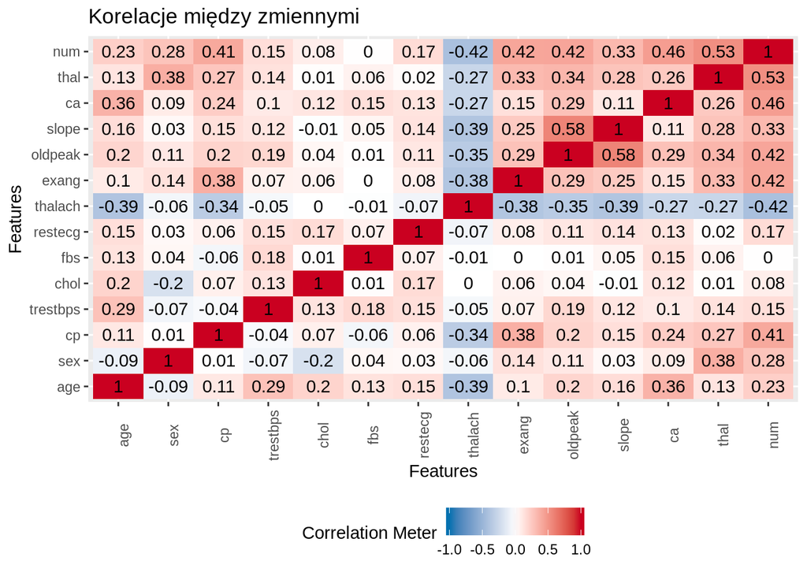

```r
plot_correlation(na.omit(data), title = "Korelacje między zmiennymi")
```

Możemy zauważyć, że num i thal mają współczynnik 0.53, co nie dziwi, gdy 7 (najwyższa wartość w thal) oznacza posiadaną wadę serca (chociaż odwracalną), więc korelacja powinna być w miarę duża. Natomiast thalach ma korelacje ujemne z kilkoma innymi zmiennymi - co nie powinno dziwić, że maksymalnie osiągane tętno jest mniejsze przy jakiś innych problemach zdrowotnych, a szczególnie przy chorobie serca (num). Ale na przykład maksymalne tętno nie zależy od cholesteroru. Taki wykres korelacji jest dobrym ukazaniem ciekawych zależności, które potem można przedstawić na oddzielnych wykresach.